# Explore and Summarize Data with the White Wine Dataset

### Due November 13, 2018

========================================================

### White Wine Data Analysis:

#### Dataset attribute information:

#### Input variables (based on physicochemical tests):

1. fixed acidity (tartaric acid - g / dm^3)
2. volatile acidity (acetic acid - g / dm^3)
3. citric acid (g / dm^3)
4. residual sugar (g / dm^3)
5. chlorides (sodium chloride - g / dm^3
6. free sulfur dioxide (mg / dm^3)
7. total sulfur dioxide (mg / dm^3)
8. density (g / cm^3)
9. pH
10. sulphates (potassium sulphate - g / dm3)
11. alcohol (% by volume)

#### Output variable (based on sensory data):

12. quality (score between 0 and 10)

#### Description of attributes:

1. fixed acidity: most acids involved with wine or fixed or nonvolatile (do not evaporate readily)
2. volatile acidity: the amount of acetic acid in wine, which at too high of levels can lead to an unpleasant, vinegar taste
3. citric acid: found in small quantities, citric acid can add ‘freshness’ and flavor to wines
4. residual sugar: the amount of sugar remaining after fermentation stops, it’s rare to find wines with less than 1 gram/liter and wines with greater than 45 grams/liter are considered sweet
5. chlorides: the amount of salt in the wine
6. free sulfur dioxide: the free form of SO2 exists in equilibrium between molecular SO2 (as a dissolved gas) and bisulfite ion; it prevents microbial growth and the oxidation of wine
7. total sulfur dioxide: amount of free and bound forms of S02; in low concentrations, SO2 is mostly undetectable in wine, but at free SO2 concentrations over 50 ppm, SO2 becomes evident in the nose and taste of wine
8. density: the density of water is close to that of water depending on the percent alcohol and sugar content
9. pH: describes how acidic or basic a wine is on a scale from 0 (very acidic) to 14 (very basic); most wines are between 3-4 on the pH scale
10. sulphates: a wine additive which can contribute to sulfur dioxide gas (S02) levels, wich acts as an antimicrobial and antioxidant
11. alcohol: the percent alcohol content of the wine
12. quality (score between 0 and 10)

# Univariate Plots Section

Below we will look at each variable from the dataset by using some basic plots to help understand the data a bit better.

```
## 'data.frame':    4898 obs. of  13 variables:
##  $ X                   : int  1 2 3 4 5 6 7 8 9 10 ...
##  $ fixed.acidity       : num  7 6.3 8.1 7.2 7.2 8.1 6.2 7 6.3 8.1 ...
##  $ volatile.acidity    : num  0.27 0.3 0.28 0.23 0.23 0.28 0.32 0.27 0.3 0.22 ...
##  $ citric.acid         : num  0.36 0.34 0.4 0.32 0.32 0.4 0.16 0.36 0.34 0.43 ...
##  $ residual.sugar      : num  20.7 1.6 6.9 8.5 8.5 6.9 7 20.7 1.6 1.5 ...
##  $ chlorides           : num  0.045 0.049 0.05 0.058 0.058 0.05 0.045 0.045 0.049 0.044 ...
##  $ free.sulfur.dioxide : num  45 14 30 47 47 30 30 45 14 28 ...
##  $ total.sulfur.dioxide: num  170 132 97 186 186 97 136 170 132 129 ...
##  $ density             : num  1.001 0.994 0.995 0.996 0.996 ...
##  $ pH                  : num  3 3.3 3.26 3.19 3.19 3.26 3.18 3 3.3 3.22 ...
##  $ sulphates           : num  0.45 0.49 0.44 0.4 0.4 0.44 0.47 0.45 0.49 0.45 ...
##  $ alcohol             : num  8.8 9.5 10.1 9.9 9.9 10.1 9.6 8.8 9.5 11 ...
##  $ quality             : int  6 6 6 6 6 6 6 6 6 6 ...
```

```
## [1] 4898   13
```

- This White wine dataset has 4898 observations with 13 variables.

```
##        X        fixed.acidity    volatile.acidity  citric.acid
##  Min.   :   1   Min.   : 3.800   Min.   :0.0800   Min.   :0.0000
##  1st Qu.:1225   1st Qu.: 6.300   1st Qu.:0.2100   1st Qu.:0.2700
##  Median :2450   Median : 6.800   Median :0.2600   Median :0.3200
##  Mean   :2450   Mean   : 6.855   Mean   :0.2782   Mean   :0.3342
##  3rd Qu.:3674   3rd Qu.: 7.300   3rd Qu.:0.3200   3rd Qu.:0.3900
##  Max.   :4898   Max.   :14.200   Max.   :1.1000   Max.   :1.6600
##  residual.sugar     chlorides       free.sulfur.dioxide
##  Min.   : 0.600   Min.   :0.00900   Min.   :  2.00
##  1st Qu.: 1.700   1st Qu.:0.03600   1st Qu.: 23.00
##  Median : 5.200   Median :0.04300   Median : 34.00
##  Mean   : 6.391   Mean   :0.04577   Mean   : 35.31
##  3rd Qu.: 9.900   3rd Qu.:0.05000   3rd Qu.: 46.00
##  Max.   :65.800   Max.   :0.34600   Max.   :289.00
##  total.sulfur.dioxide    density             pH          sulphates
##  Min.   :  9.0        Min.   :0.9871   Min.   :2.720   Min.   :0.2200
##  1st Qu.:108.0        1st Qu.:0.9917   1st Qu.:3.090   1st Qu.:0.4100
##  Median :134.0        Median :0.9937   Median :3.180   Median :0.4700
##  Mean   :138.4        Mean   :0.9940   Mean   :3.188   Mean   :0.4898
##  3rd Qu.:167.0        3rd Qu.:0.9961   3rd Qu.:3.280   3rd Qu.:0.5500
##  Max.   :440.0        Max.   :1.0390   Max.   :3.820   Max.   :1.0800
##     alcohol         quality
##  Min.   : 8.00   Min.   :3.000
##  1st Qu.: 9.50   1st Qu.:5.000
##  Median :10.40   Median :6.000
##  Mean   :10.51   Mean   :5.878
##  3rd Qu.:11.40   3rd Qu.:6.000
##  Max.   :14.20   Max.   :9.000
```

*Converted Quality from an integer to a Factor variable so that we can compare across different wine qualities.*

#### *Quality*:

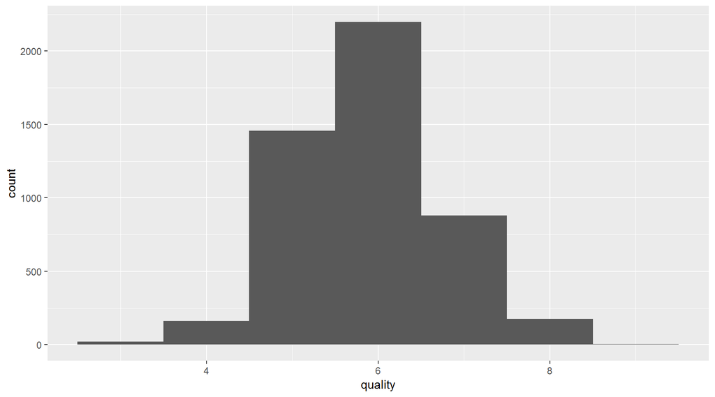

```
##    Min. 1st Qu.  Median    Mean 3rd Qu.    Max.
##   3.000   5.000   6.000   5.878   6.000   9.000
```

Mean quality of wine is 5.878 with a range from 3 to 9 (10 being the best). No wine has a quality of 10.

#### *Fixed acidity*

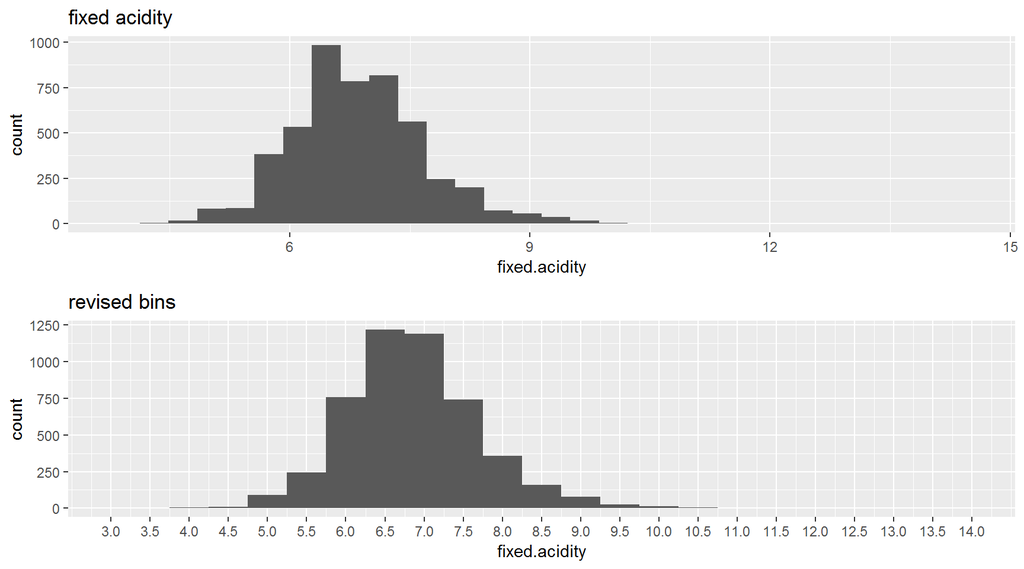

The graph shows a bit of a long tail to the right. With a finer binwidth we can see the majority of the fixed acidity is between 6 and 8.

#### *Volatile acidity*:

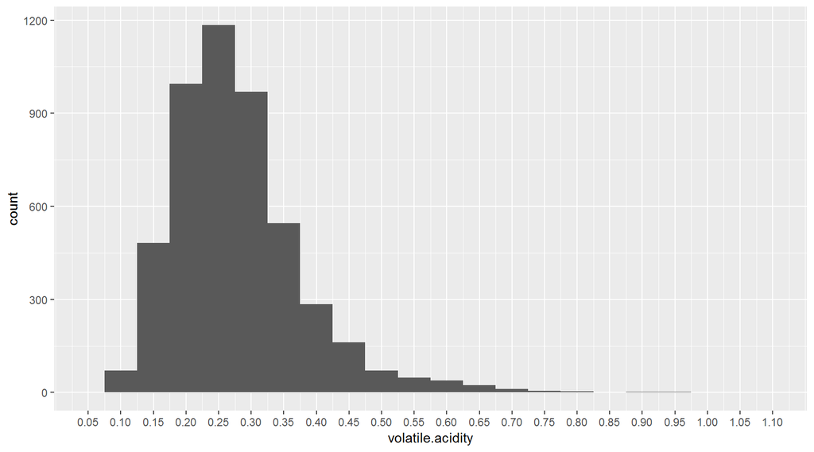

With a finer binwidth we can see that most wine have a volatile acidity (acetic acid) between 0.15 to 0.4 g/liter. Because high amounts of acetic acid leaves a vinegary taste, I wonder if this affects the quality score.

#### *Citric acid*:

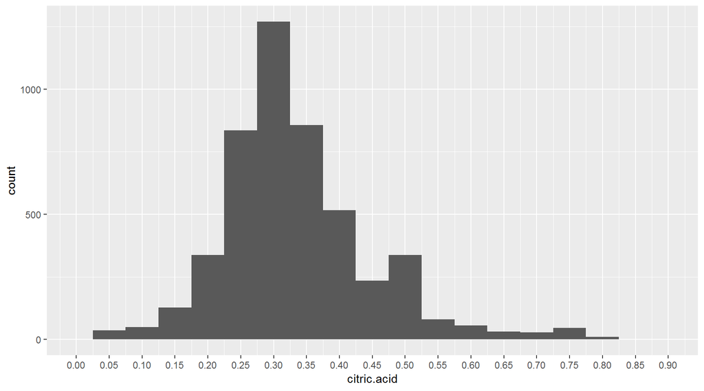

The majority of citric acid level are between 0.2 g/liter and 0.5 g/liter with a peak around 0.3 g/liter. A few with high levels of citric acid also exists.

#### *Residual Sugar*:

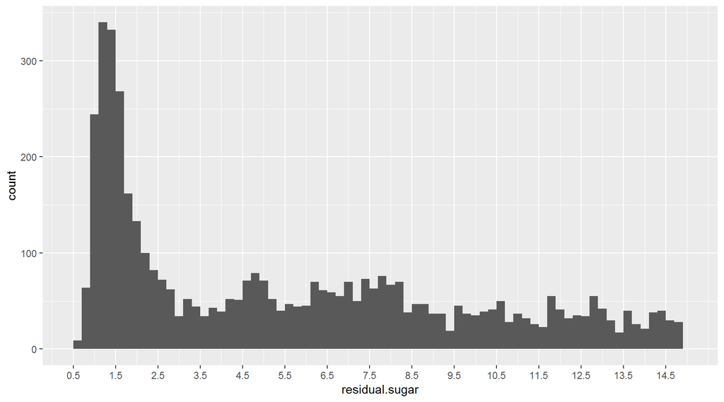

The residual sugar seems to occupy a very wide range, up to 65 g/liter. There is a sweetness level for everyone.

#### *Chlorides*:

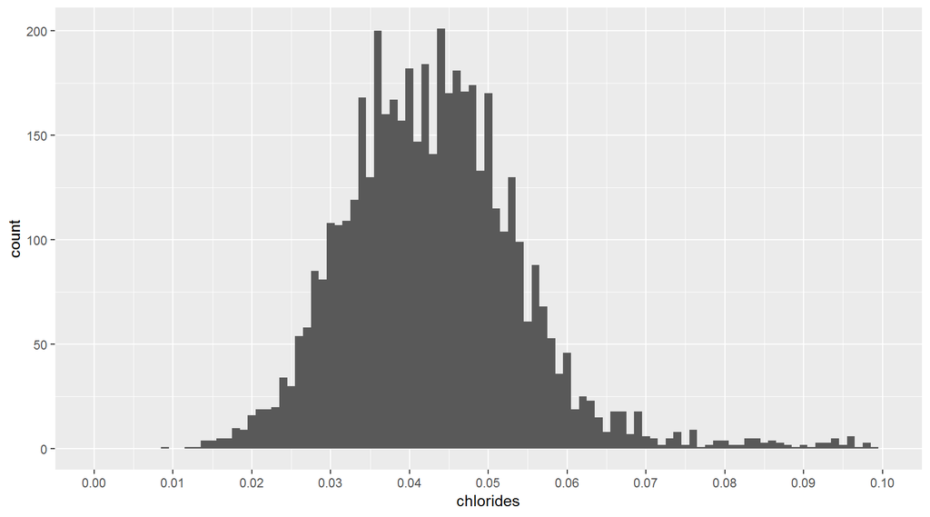

Chlorides is the amount of salt in the wine, and the majority of the wine ranges from 0.02 g/liter to 0.05 g/liter, with a mean of 0.04 g/liter. Very few have high quantity of chlorides (more than 0.06 g/liter).

#### *Free Sulfur Dioxide*:

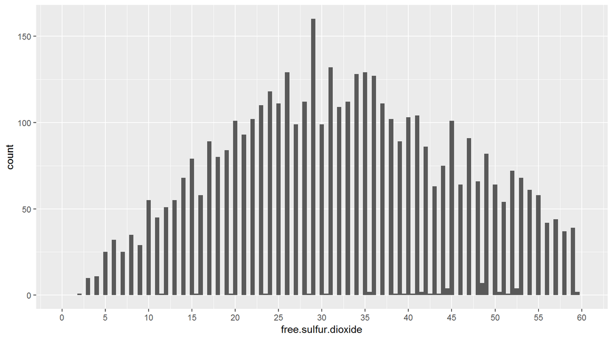

The distribution for free sulfur dioxide seems a normal one. The majority fall between 10 mg/liter to 50 mg/liter with a mean of 35 mg/liter.

Free sulfur dioxide is used to prevent microbial growth and wine oxidation. Free sulfur dioxide over 50 ppm (parts per million = mg/liter) is noticeable to the nose and to the taste. Can this affect the rating?

#### *Total Sulfur Dioxide*:

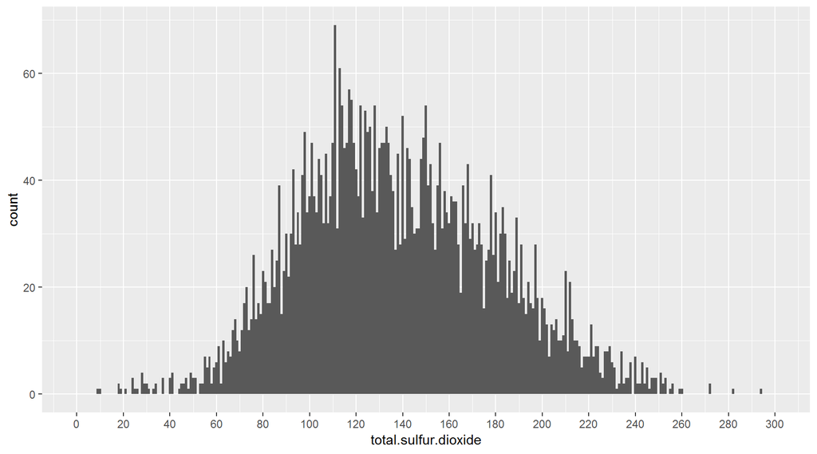

The Total sulfur dioxide has a normal distribution with a range of 9 to 440 mg/liter with a mean of 138.4 mg/liter.

#### *Density*:

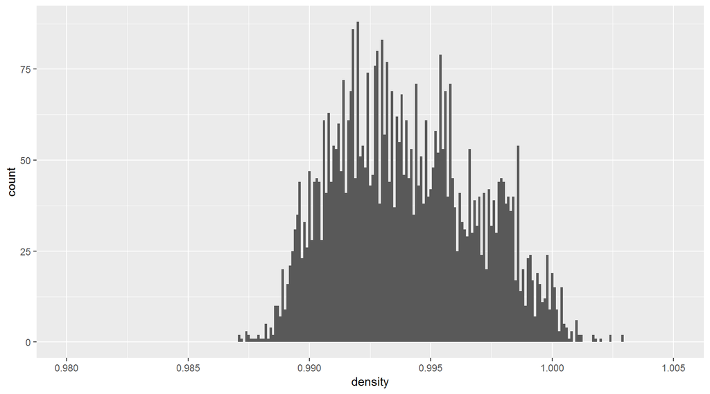

Density of water has a normal distribution with a mean of 0.9940 with outliers over 1.002 (The density of water in wine is close to that of water itself).

#### *pH*:

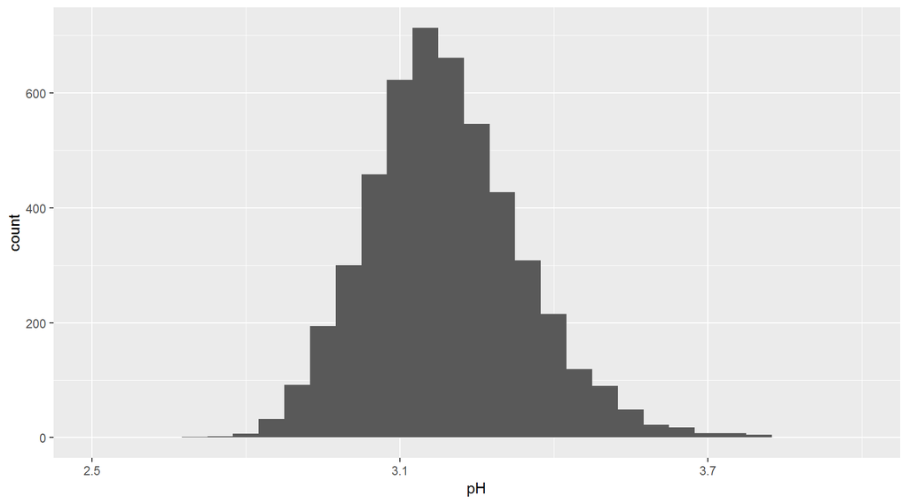

Typical pH of wine is around 3 - 4. Zero is very acidic and this dataset has a pH mean at 3.18. It seems most wines are nearer to this acidic spectrum than at the very basic level of 14.

#### *Sulphates*:

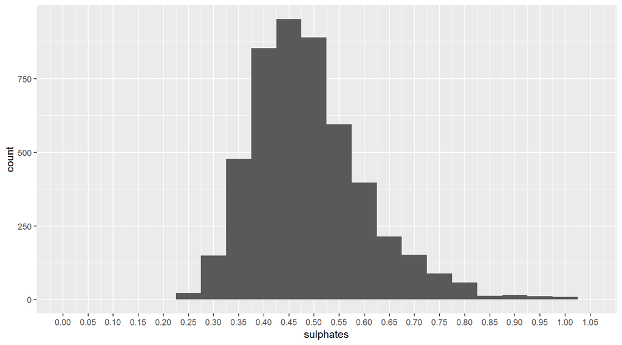

Sulphates is a wine additive that can contribute to sulfur dioxide gas. The mean is about half gram per liter.

#### *Alcohol*:

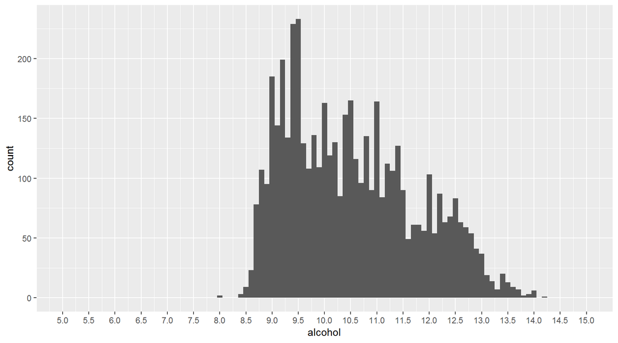

It seems that the majority of wine have alcohol content of 12% or less. Alcohol content should affect the quality score.

# Univariate Analysis

#### What is/are the main feature(s) of interest in your dataset?

The main feature of interest will be the Quality rating of the wine and how/if other features can influence this.

#### What other features in the dataset do you think will help support your investigation into your feature(s) of interest?

As I was looking at the individual variables, alcohol, free sulfur dioxide, and volatile acidity, in one way or another, affect the taste.

#### Did you create any new variables from existing variables in the dataset?

It seems the different acids could be combined but I do not see a use as of now. Quality was converted from integer to factor.

#### Of the features you investigated, were there any unusual distributions? Did you perform any operations on the data to tidy, adjust, or change the form of the data? If so, why did you do this?

- All of the distribution seems a normal one except for Residual sugar. Residual sugar spans a wide range so that means there are many sweetness levels.
- pH: considers to be very acidic at zero and the majority of the white wine is closer to that end of the spectrum at 3 or 4.
- Free sulfur dioxide over 50 mg/liter becomes noticeable in the nose and taste of the wine.
- Other than a few outliers in some of the variables, I believe the dataset is relatively clean.

# Bivariate Plots Section

#### Examining the main variables of:

- Alcohol content
- Volatile Acidity
- Free sulfur dioxide

#### *Alcohol vs. Quality*:

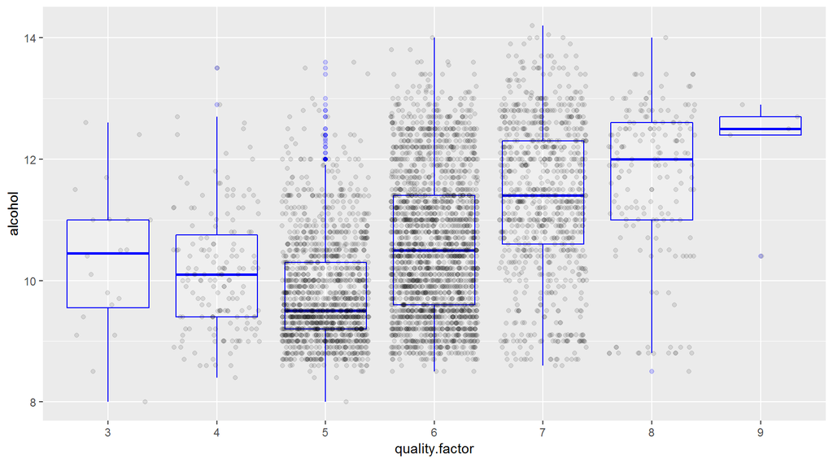

#### *Volatile Acidity vs. Quality*:

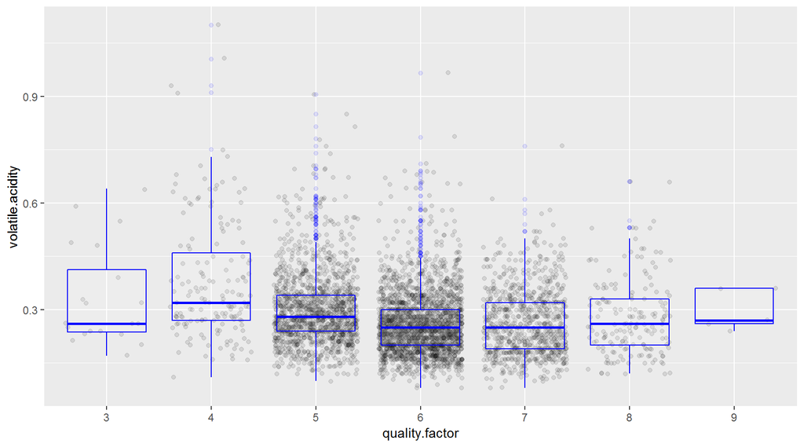

Because higher levels of acetic acid will result in unpleasant taste, many average quality wine (rating of 5-7) have low levels of acetic acid (less than 0.5 g/liter). The higher quality wine seems to have lower number of acetic acids (from the graph: less bunching of the dots).

#### *Sulfur dioxide vs. Quality*:

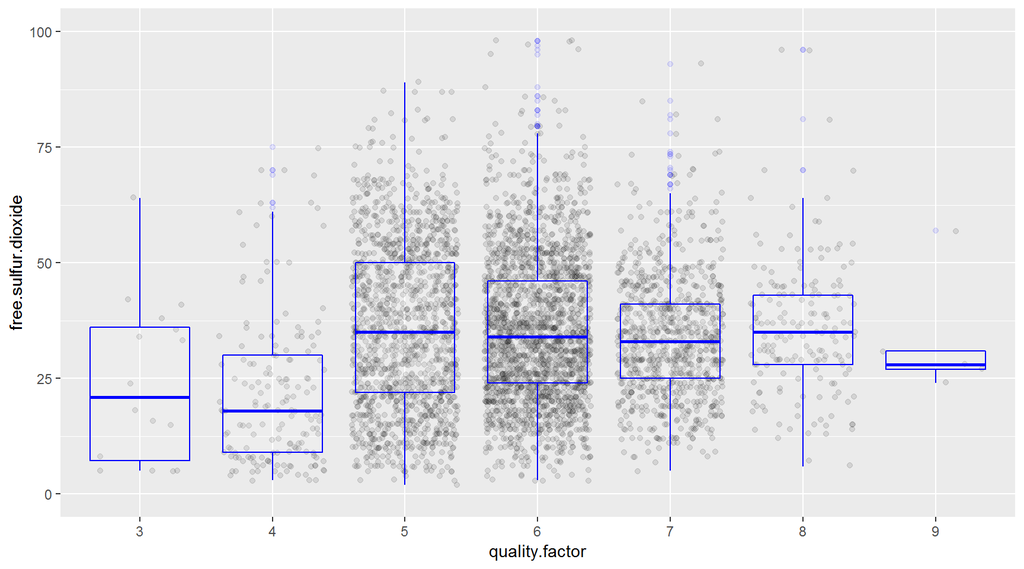

Although over 50 mg/liter of sulfur dioxide the tastes can be evident, I thought lower SO2 levels would result in higher quality score, but the chart shows that a lot of data points are bunching around rating of 6. It does not seem there is a strong relationship between SO2 and quality.

#### *Alcohol vs. volatile acidity*:

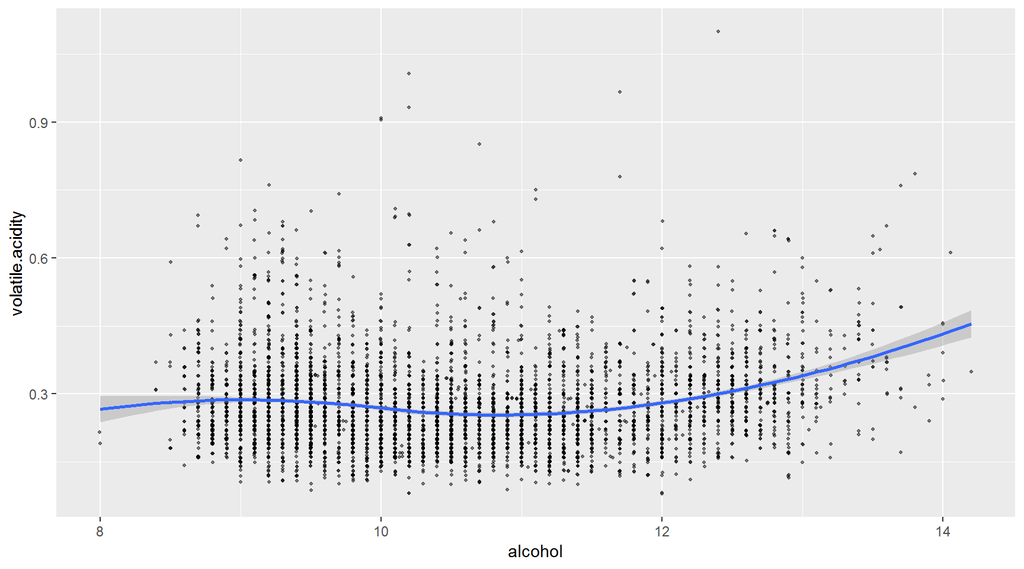

The Alcohol and acidity have a non-linear relationship.

#### *Alcohol vs. free sulfur dioxide*:

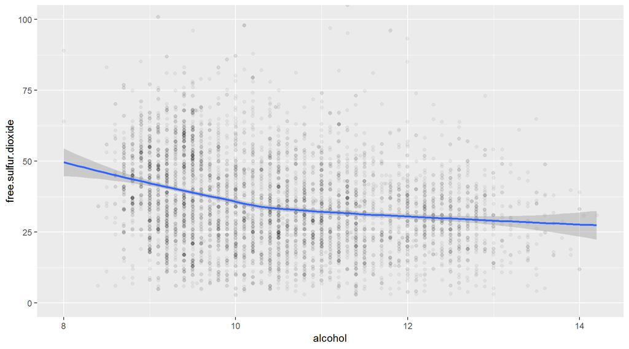

There appears a negative relationship between free sulfur dioxide and alcohol content; as alcohol content increases, free sulfur dioxide decreases. I would like to investigate this further.

#### *Alcohol vs. pH*:

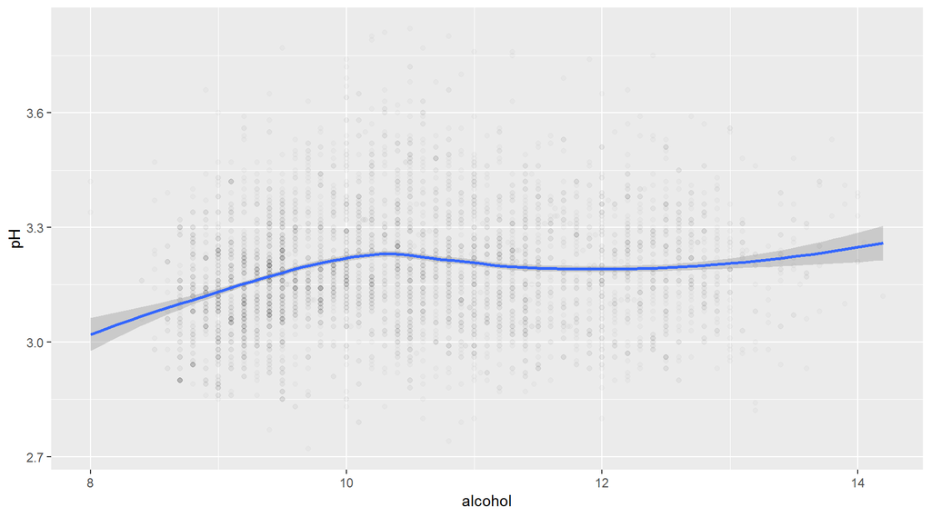

There seems to be a slight relationship between pH and alcohol up to the 10% alcohol content. The relationship seems non-linear after the 10.5% level.

# Bivariate Analysis

#### Talk about some of the relationships you observed in this part of the investigation. How did the feature(s) of interest vary with other features in the dataset?

- Expected more number of higher scores with increasing Alcohol content.
- The amount of acetic acid (volatile acidity) was not surprising in that it clumped around the score of 6. This does not seem to affect the quality score.

#### Did you observe any interesting relationships between the other features (not the main feature(s) of interest)?

- pH and Alcohol seems interesting, in that, acidic levels remain constants with increasing Alcohol content.

# Multivariate Plots Section

Since high levels of high acetic acid leaves to an unpleasant, vinegar taste, I’m going to look at it in relation to alcohol and quality:

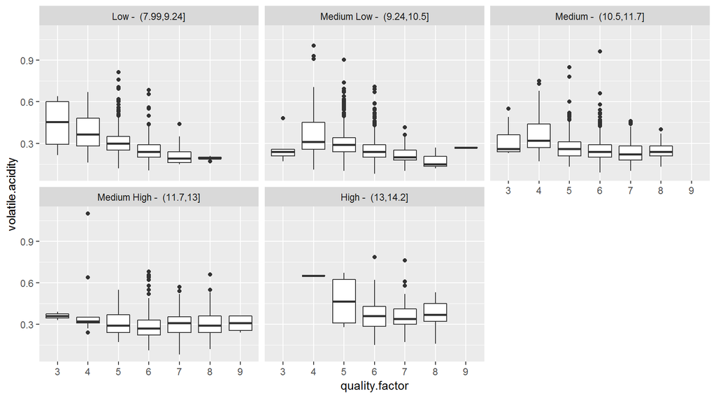

Also, high levels of free sulfur dioxide affects taste, I’m going to examine it in relation to alcohol and quality:

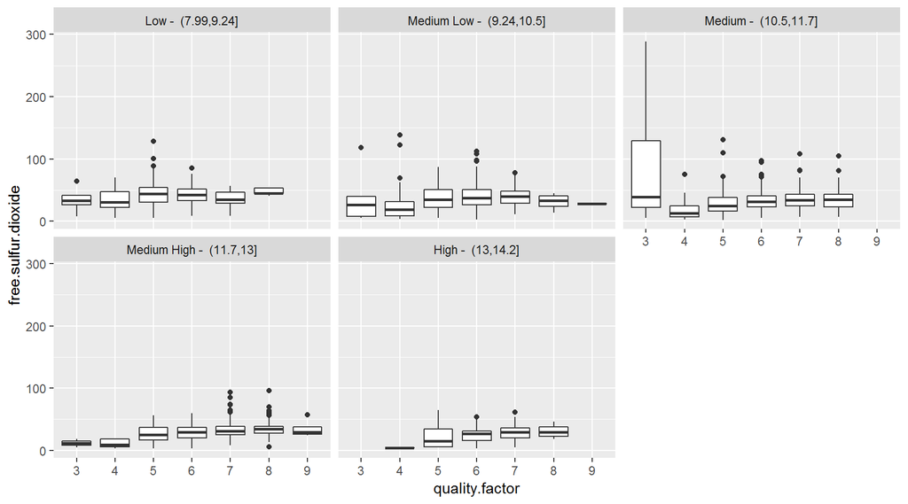

The median free sulfur dioxide seem to be below 50mg/liter, the level where it affects smell and taste. At those levels it seems quality rating is better in all alcohol levels.

# Multivariate Analysis

#### Talk about some of the relationships you observed in this part of the investigation. Were there features that strengthened each other in terms of looking at your feature(s) of interest?

As acetic acid levels decreases, the quality rating increases - this is most prevalent in the lower levels of alcohol contents. Even with the acetic acid outliers, these points do not appear with the high quality scores.

#### Were there any interesting or surprising interactions between features?

I also thought that free sulfur dioxide and alcohol would affect quality rating.

# Final Plots and Summary

#### Plot One: Alcohol vs. Quality

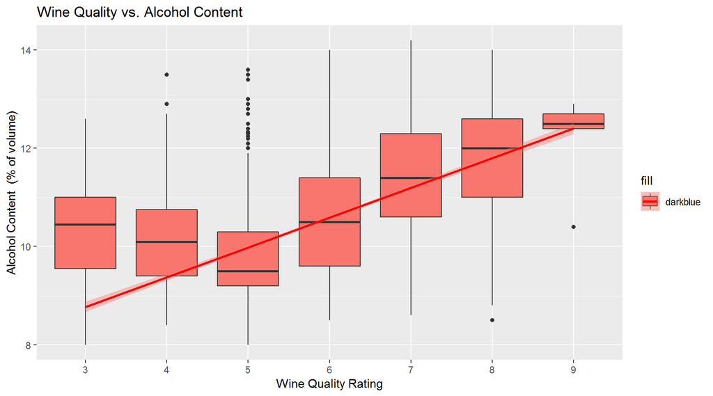

```
##
##  Pearson's product-moment correlation
##
## data:  quality and alcohol
## t = 33.858, df = 4896, p-value < 2.2e-16
## alternative hypothesis: true correlation is not equal to 0
## 95 percent confidence interval:
##  0.4126015 0.4579941
## sample estimates:
##       cor
## 0.4355747
```

#### Plot Two: Free sulfur dioxide, Alcohol vs. Quality

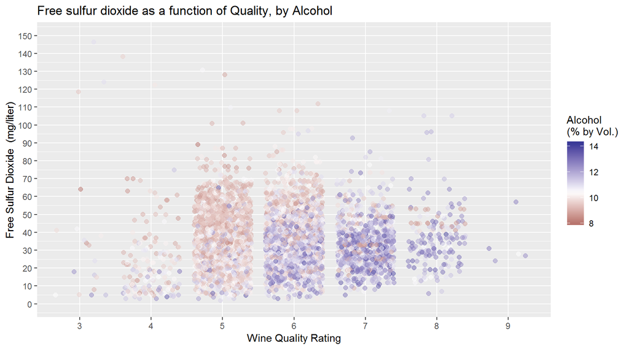

#### Description Two

I selected free sulfur dioxide because, in high levels, it affects smell and taste. It appears most wines are bunched around 5 to 7 ratings. Wine with low levels of free sulfur dioxide with higher alcohol concentration have higher quality rating.

#### Plot Three: Volatile acidity, Alcohol vs. Quality

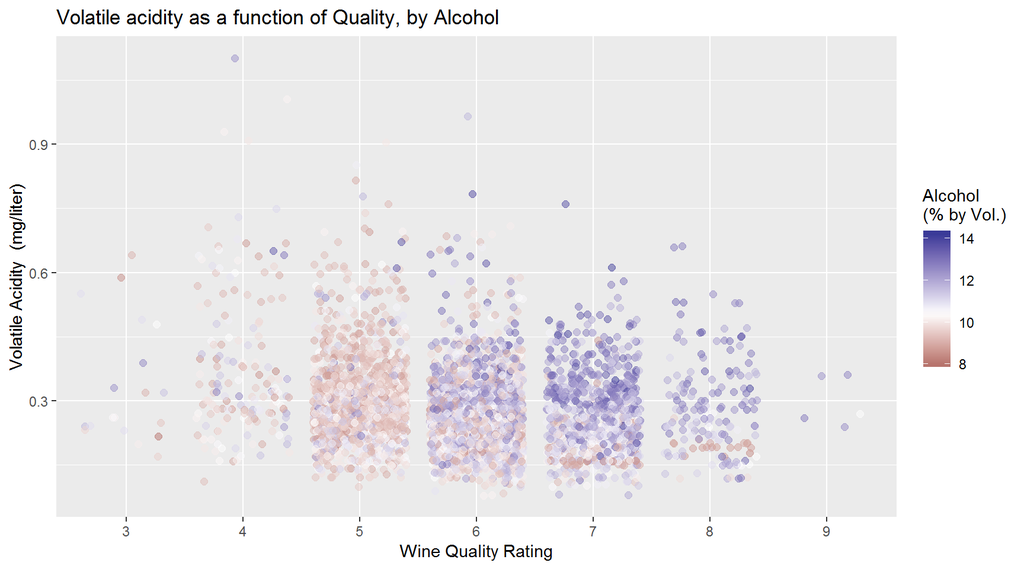

#### Description Three

Here I keyed on the feature of volatile acidity because in high levels it also affects taste. We can see that high concentrations of alcohol, with lower levels of volatile acidity, we get higher quality ratings.

# Reflection

- What was interesting, initially I thought residual sugar would be an important factor in wine quality until we saw that it is a very wide ranging feature. There seems to be a sweetness level for all consumer preference so I chose not to key on it.
- Certain chemicals at high levels can affect smell and tastes, such as volatile acidity and free sulfur dioxide.
- I mainly chose the chemicals that I thought would influence smell and tastes to further investigate because I believed that would ultimately affect quality rating.
- In the end we found that alcohol is an important factor as well. It seems alcohol can negate some of the features that would eventually affect smell and taste, as we saw in the previous 2 charts; so alcohol content is an important feature.
- I found it a bit difficult in dealing with the features of the dataset, not really understanding the chemicals.
- Further interest in the investigation would be on the selling side of the these wine; which type of white wine sells better, and where/region. Perhaps looking at whether or not the quality of wine reflect in the sales, etc.